# Classification of τ → μμμ

劉又瑄、藍雍淵、李承志、李亞庭

2019/06/19

# Density of variables

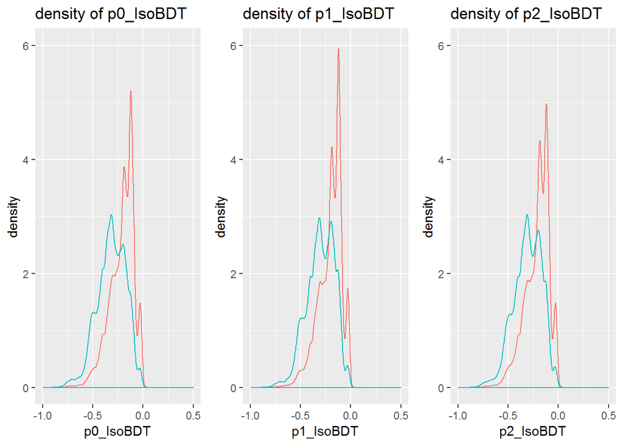

μ(1-)、μ(2-)、μ(＋) 三個isolation變數分佈相似， 而數值介於-0.1到-0.2時τ 不會發生衰變的機率也相對高

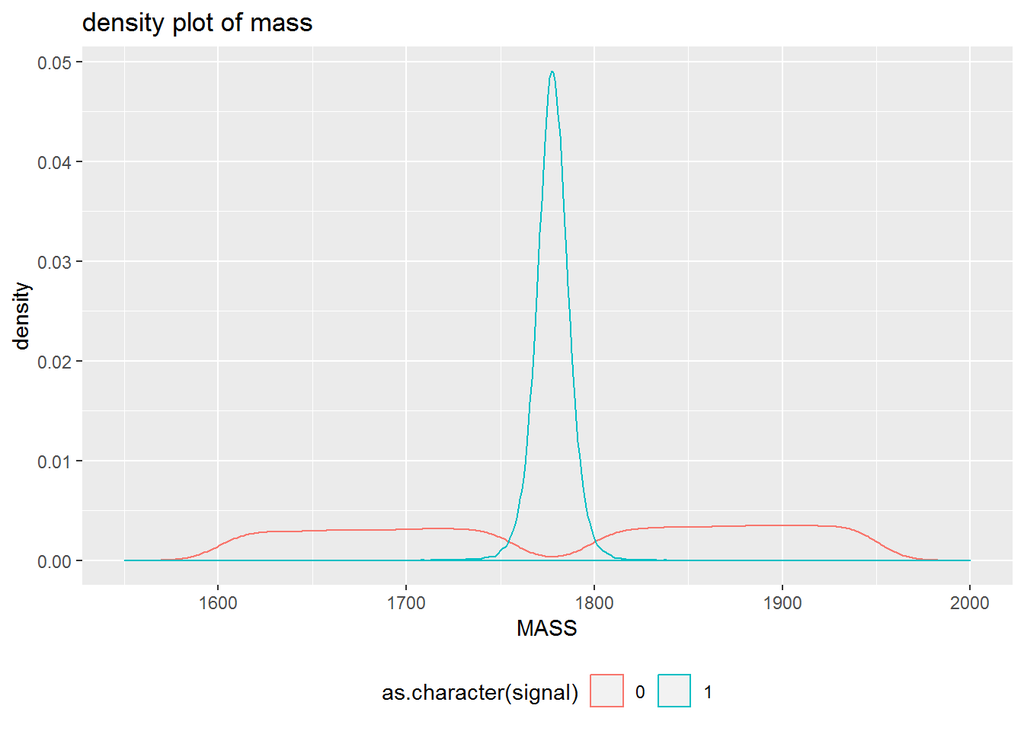

x軸為tau子的質量（單位為百萬電子伏特 Mev/c^2） tau子的質量大約介於1750-1820 Mev/c^2時，發生衰變的機率是相當大的 而在其他質量不會發生衰變

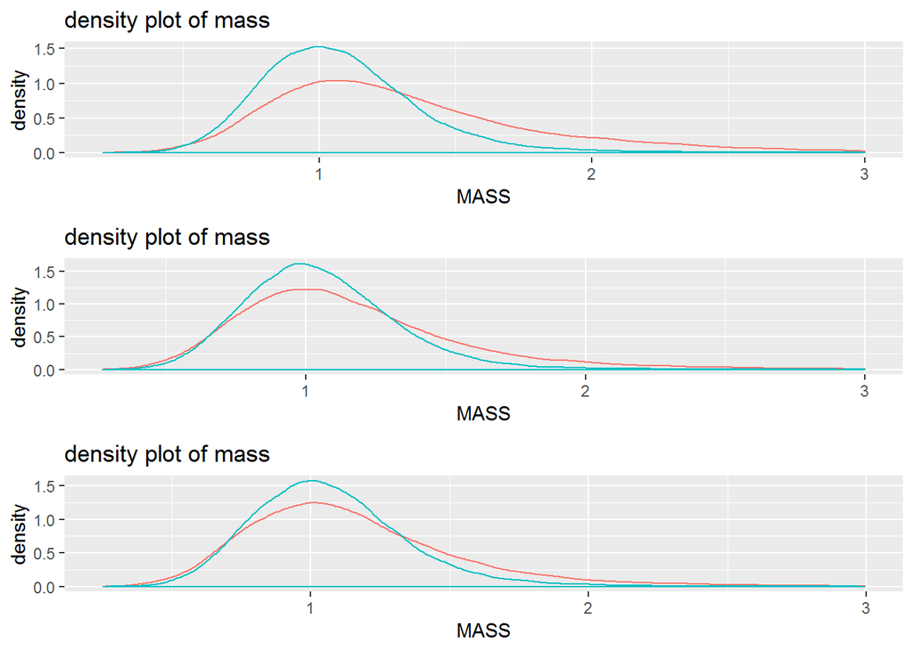

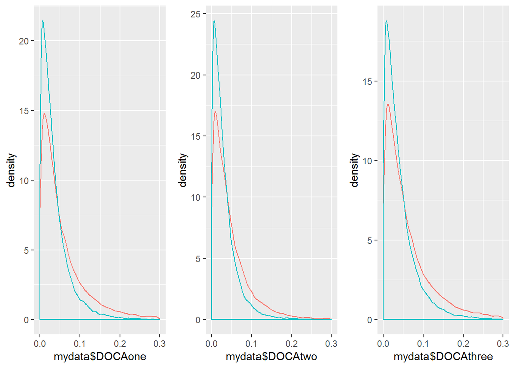

圖形由左至右的X軸分別為 μ(1-)到μ(2-)的距離，μ(2-)到μ(＋)的距離，μ(1-)到μ(+)的距離 我們可以發現的是三者距離的分布差不多，兩者之間距離越近τ 會發生衰變得機率也相對高

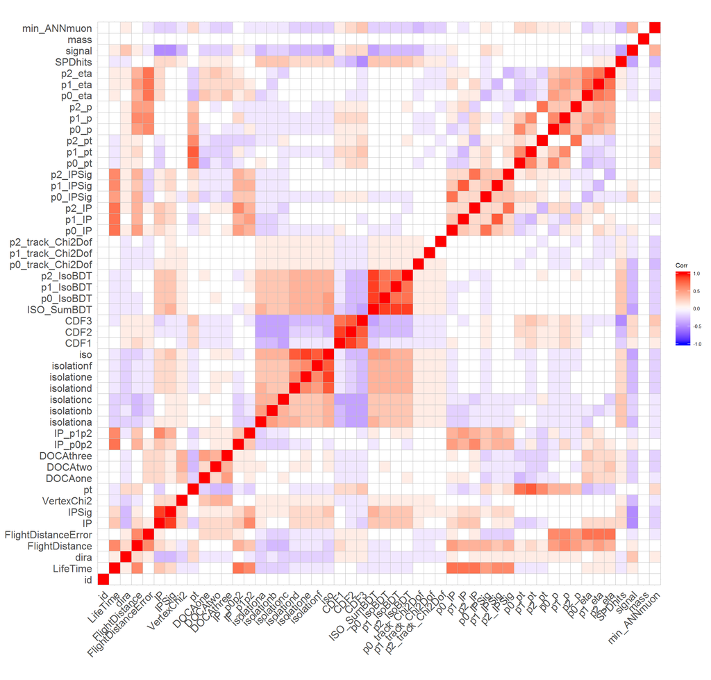

在這個熱圖偏中間的部分，可以看到CDF1 ~ CDF3(Cone isolation variable), 和Isolation系列的變數(Track isolation variable)多為負相關的關係， 反之Isolation系列的變數彼此皆有一定程度的相關性。

再往右上一點看到三個μ的IP系列變數(Impact parameter)也彼此呈滿高的相關性。

而在三個μ與動量相關的pt/p/eta，也就是(Transverse)Momentum/Pseudorapidity中，彼此之間有非常明顯的關聯性，但同時也可以發現它們與IP系列變數卻呈負相關。

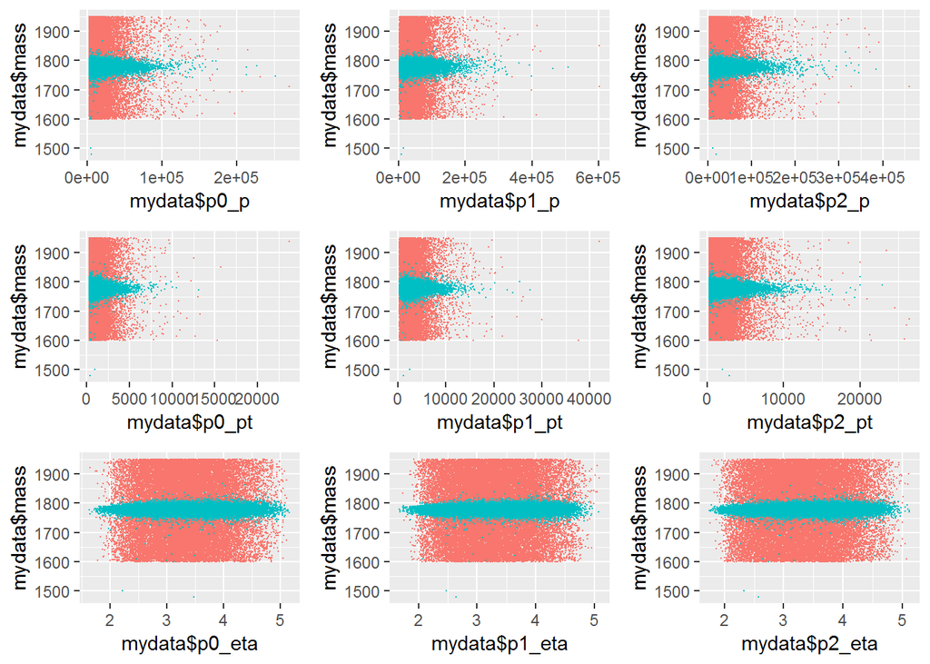

這九個圖形分別是 μ(1-)、μ(2-)、μ(＋) 中三個關於角動量和τ子質量的散佈圖， 可以發現不論動量變數大小為何，只要質量介於1750-1820Mev/c^2時， 就會發生衰變。

**肆●預測分析**  
在此部分將使用下列幾種方法：

1. logistic regression without any variable/model selection  
2. logistic regression with one method of variable/model selections  
3. logistic rigid regression  
4. logistic lasso regression  
5. Discriminant Analysis  
6. Decision Tree  
7. k-Nearest Neighbor Classification  
8. Bagging  
9. Random Forest  
10. Support Vector Machines

**1. logistic regression without any variable/model selection**  
首先，先針對尚未進行data transformation的原始反應變數進行羅吉斯迴歸 由總資料80%的training dataset中的training data(70%)訓練出的model結果如下：

```
## [1] 0.486008
```

```
##          Sensitivity          Specificity       Pos Pred Value
##            0.8128938            0.9065150            0.8429960
##       Neg Pred Value            Precision               Recall
##            0.8869582            0.8429960            0.8128938
##                   F1           Prevalence       Detection Rate
##            0.8276713            0.3817543            0.3103257
## Detection Prevalence    Balanced Accuracy
##            0.3681224            0.8597044
```

**2. logistic regression with one method of variable/model selections**

```
## [1] 23552.55
```

```
## [1] 23538.1
```

```
## [1] 0.08873113
```

```
## [1] 0.1282
```

```
## [1] 0.8718
```

```
## [1] 0.9012272
```

```
## [1] 0.8240427
```

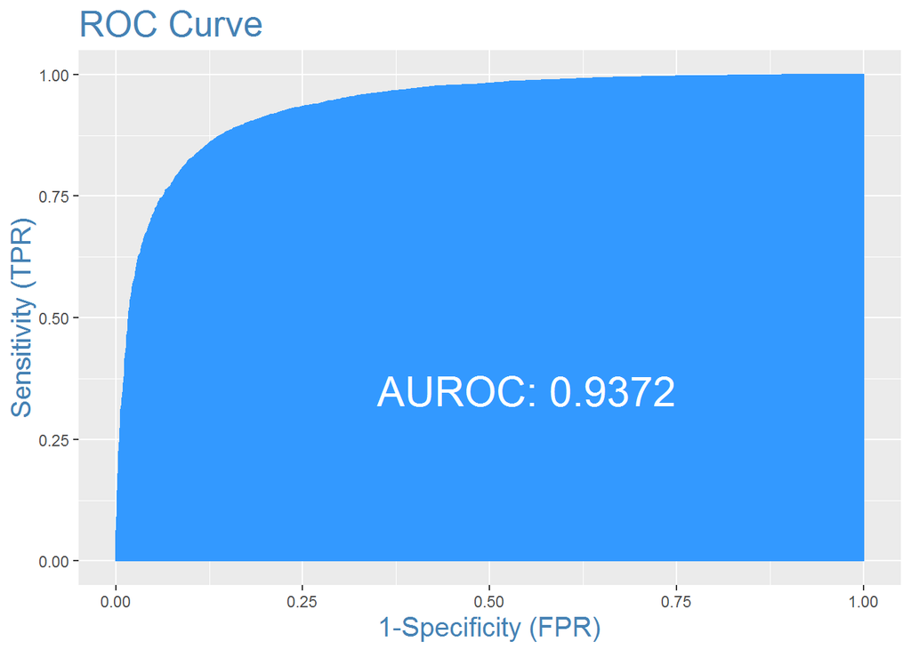

**3. logistic rigid regression**

```
## [1] 0.4862639
```

```
##          Sensitivity          Specificity       Pos Pred Value
##            0.7968977            0.9083109            0.8429328
##       Neg Pred Value            Precision               Recall
##            0.8786797            0.8429328            0.7968977
##                   F1           Prevalence       Detection Rate
##            0.8192691            0.3817543            0.3042191
## Detection Prevalence    Balanced Accuracy
##            0.3609055            0.8526043
```

**4. logistic lasso regression**

```
## [1] 0.4862773
```

```
##          Sensitivity          Specificity       Pos Pred Value
##            0.7883341            0.9035219            0.8345878
##       Neg Pred Value            Precision               Recall
##            0.8736253            0.8345878            0.7883341
##                   F1           Prevalence       Detection Rate
##            0.8108018            0.3817543            0.3009499
## Detection Prevalence    Balanced Accuracy
##            0.3605971            0.8459280
```

**5. Discriminant Analysis**  
在此部份中，我們以一次判別分析(Linear Discriminant Analysis，LDA)來做預測。 首先，先以80%的training data中的70% training來訓練模型，並對30%的validation data檢驗結果

```
## Confusion Matrix and Statistics
##
##           Reference
## Prediction    0    1
##          0 4984  939
##          1 1205 9084
##
##                Accuracy : 0.8678
##                  95% CI : (0.8624, 0.8729)
##     No Information Rate : 0.6182
##     P-Value [Acc > NIR] : < 2.2e-16
##
##                   Kappa : 0.7175
##  Mcnemar's Test P-Value : 1.046e-08
##
##             Sensitivity : 0.8053
##             Specificity : 0.9063
##          Pos Pred Value : 0.8415
##          Neg Pred Value : 0.8829
##              Prevalence : 0.3818
##          Detection Rate : 0.3074
##    Detection Prevalence : 0.3653
##       Balanced Accuracy : 0.8558
##
##        'Positive' Class : 0
##
```

接著針對20%的test data做5次bootstrap cross-testing並計算平均風險，其分類正確率、分類錯誤率、sensitivity與specificity和AUC分別如下：

| model | 分類正確率 | 分類錯誤率 | sensitivity | specificity | rmse | AUC |
| --- | --- | --- | --- | --- | --- | --- |
| LDA(with mass) | 87.80% | 12.20% | 0.8261 | 0.9100 | 0.3491 | 0.8680 |

然而，如同探索性資料分析所說，由於本份資料的 mass 會相當程度的幫助預測結果，並且此kaggle比賽原先是規定不能以mass這個變數來做預測的。 故以下呈現拿掉mass之下的結果。 先以80%的training data中的70% training來訓練模型，並對30%的validation data檢驗結果

```
## Confusion Matrix and Statistics
##
##           Reference
## Prediction    0    1
##          0 4978  940
##          1 1211 9083
##
##                Accuracy : 0.8673
##                  95% CI : (0.862, 0.8725)
##     No Information Rate : 0.6182
##     P-Value [Acc > NIR] : < 2.2e-16
##
##                   Kappa : 0.7165
##  Mcnemar's Test P-Value : 5.828e-09
##
##             Sensitivity : 0.8043
##             Specificity : 0.9062
##          Pos Pred Value : 0.8412
##          Neg Pred Value : 0.8824
##              Prevalence : 0.3818
##          Detection Rate : 0.3071
##    Detection Prevalence : 0.3650
##       Balanced Accuracy : 0.8553
##
##        'Positive' Class : 0
##
```

接著針對20%的test data做5次bootstrap cross-testing並計算平均風險，其分類正確率、分類錯誤率、sensitivity與specificity和AUC分別如下：

| model | 分類正確率 | 分類錯誤率 | sensitivity | specificity | rmse | AUC |
| --- | --- | --- | --- | --- | --- | --- |
| LDA(without mass) | 87.57% | 12.43% | 0.8205 | 0.9098 | 0.3524 | 0.8652 |

最後畫出拿掉mass情況的20%的test data的ROC curve：

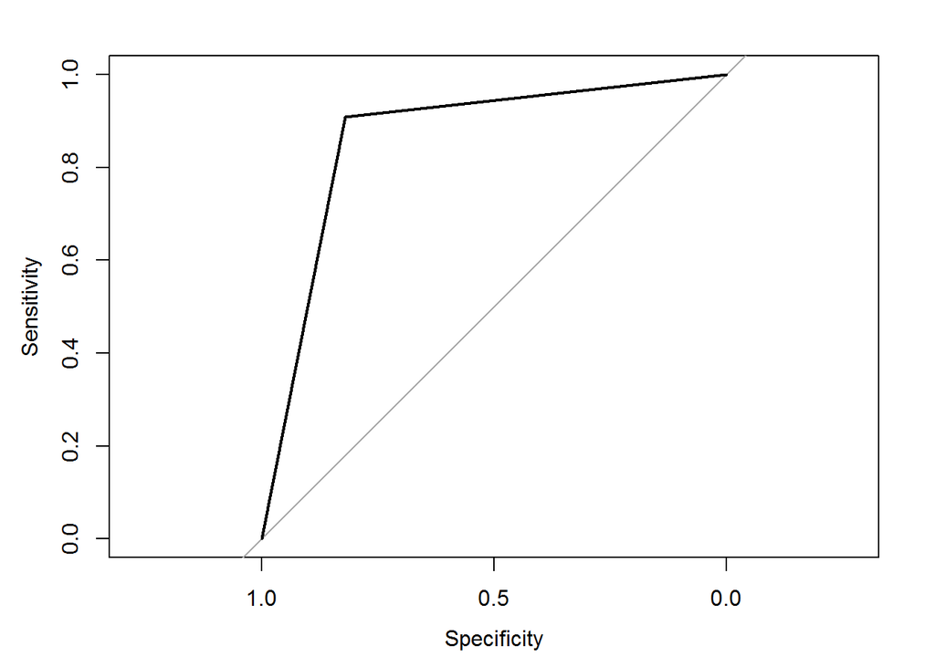

**6. Decision Tree**  
先以80%的training data中的70% training來訓練decision tree模型，訓練出的樹狀結構如下：

[figure not shown]

我們可以先看到在資料集含有mass這個變數時，decision tree 出現了連續兩個節點都以mass來預測的奇怪情形。

接著針對30%的 validation data 檢驗結果

```
## Confusion Matrix and Statistics
##
##           Reference
## Prediction    0    1
##          0 5997  210
##          1  192 9813
##
##                Accuracy : 0.9752
##                  95% CI : (0.9727, 0.9775)
##     No Information Rate : 0.6182
##     P-Value [Acc > NIR] : <2e-16
##
##                   Kappa : 0.9475
##  Mcnemar's Test P-Value : 0.3965
##
##             Sensitivity : 0.9690
##             Specificity : 0.9790
##          Pos Pred Value : 0.9662
##          Neg Pred Value : 0.9808
##              Prevalence : 0.3818
##          Detection Rate : 0.3699
##    Detection Prevalence : 0.3829
##       Balanced Accuracy : 0.9740
##
##        'Positive' Class : 0
##
```

我們可以發現，儘管決策樹篩選的過程結果奇特，卻有高達97.52%的Accuracy

接著我們直接針對沒有mass的資料集再做一次

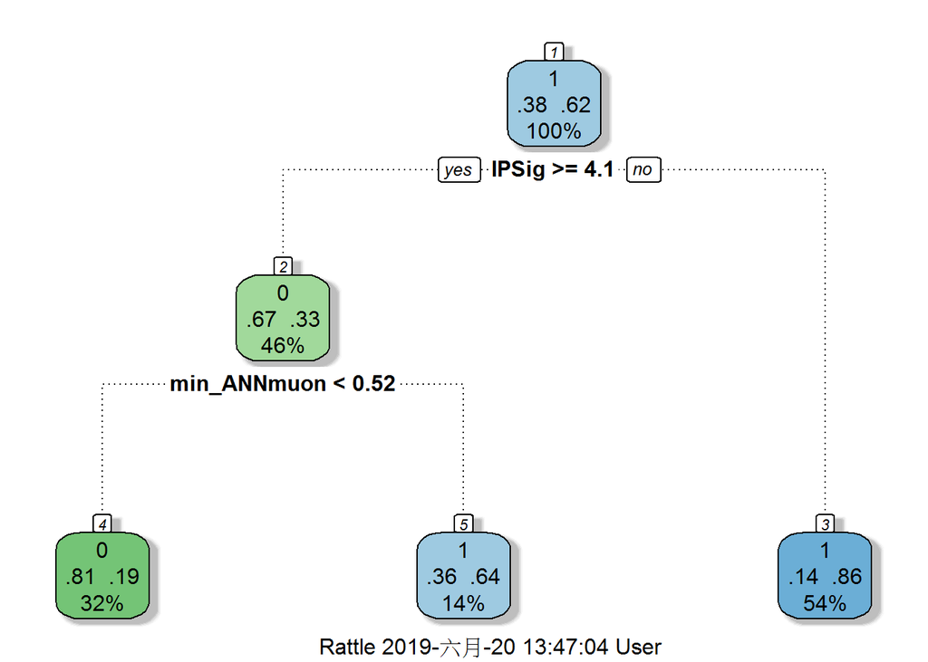

可以看到第一層是以 IPsig (Significance of Impact Parameter) 來做決策，第二層則是以min_ANNmuon (denotes the minimum of the three muons ANN)做決策。

檢視針對30%的 validation data 的分類效果

```
## Confusion Matrix and Statistics
##
##           Reference
## Prediction    0    1
##          0 4236 1057
##          1 1953 8966
##
##                Accuracy : 0.8143
##                  95% CI : (0.8083, 0.8203)
##     No Information Rate : 0.6182
##     P-Value [Acc > NIR] : < 2.2e-16
##
##                   Kappa : 0.5955
##  Mcnemar's Test P-Value : < 2.2e-16
##
##             Sensitivity : 0.6844
##             Specificity : 0.8945
##          Pos Pred Value : 0.8003
##          Neg Pred Value : 0.8211
##              Prevalence : 0.3818
##          Detection Rate : 0.2613
##    Detection Prevalence : 0.3265
##       Balanced Accuracy : 0.7895
##
##        'Positive' Class : 0
##
```

拿掉mass後，accuracy由97.52%下降至81.43%。

接著比較有無mass的狀況，針對20%的test data做5次bootstrap cross-testing 計算平均風險，其分類正確率、分類錯誤率、sensitivity與specificity和AUC分別如下：

| model | 分類正確率 | 分類錯誤率 | sensitivity | specificity | rmse | AUC |
| --- | --- | --- | --- | --- | --- | --- |
| Decision Tree(with mass) | 97.67%% | 2.33%% | 0.9696 | 0.9810 | 0.1525 | 0.9753 |
| Decision Tree(without mass) | 81.76% | 18.24% | 0.6895 | 0.8970 | 0.4269 | 0.7932 |

最後畫出Decision tree model中，拿掉mass情況的20%的test data的ROC curve：

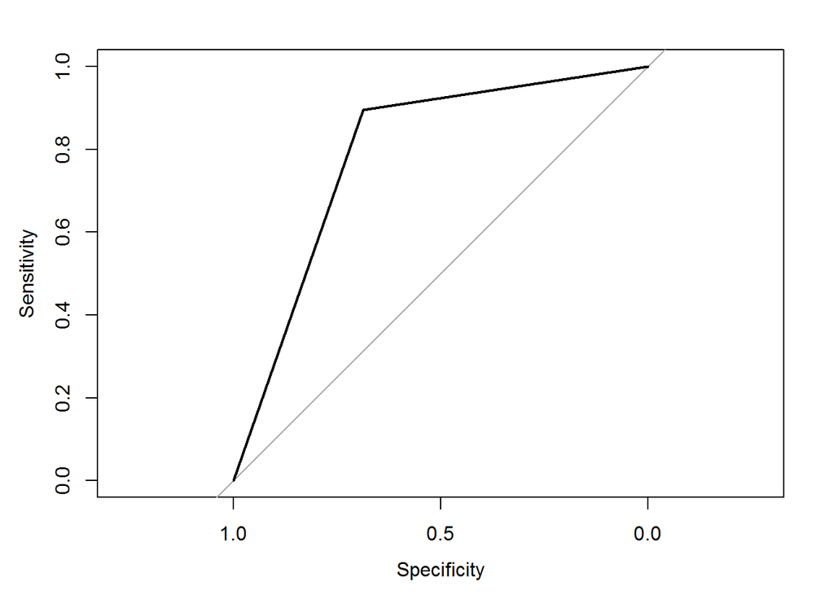

**7. k-Nearest Neighbor Classification**  
首先，先由80%的training data中的70% training來tune parameter k

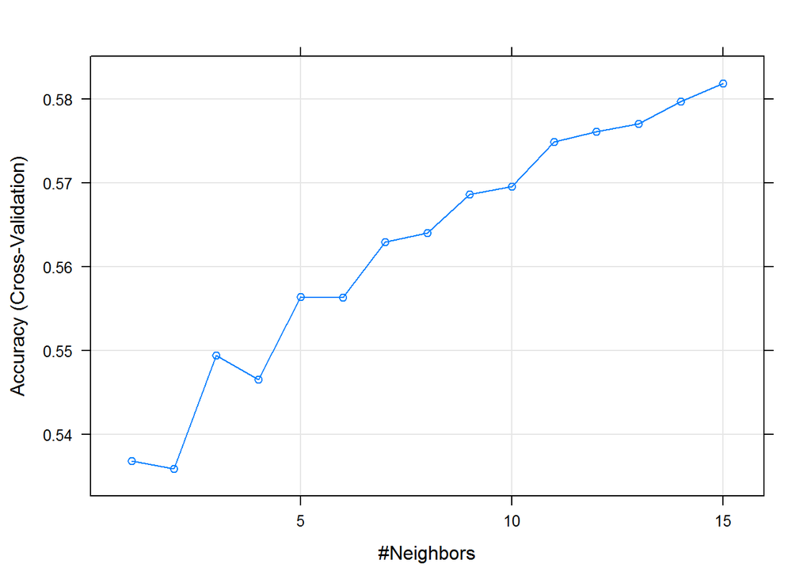

由此可知，k取15能夠有較好的結果。  
接著對30%的validation data檢驗結果

```
## Confusion Matrix and Statistics
##
##           Reference
## Prediction    0    1
##          0 1128 1714
##          1 5061 8309
##
##                Accuracy : 0.5821
##                  95% CI : (0.5745, 0.5897)
##     No Information Rate : 0.6182
##     P-Value [Acc > NIR] : 1
##
##                   Kappa : 0.0126
##  Mcnemar's Test P-Value : <2e-16
##
##             Sensitivity : 0.18226
##             Specificity : 0.82899
##          Pos Pred Value : 0.39690
##          Neg Pred Value : 0.62147
##              Prevalence : 0.38175
##          Detection Rate : 0.06958
##    Detection Prevalence : 0.17530
##       Balanced Accuracy : 0.50563
##
##        'Positive' Class : 0
##
```

並且其rmse如下：

```
## [1] 0.6464521
```

接著針對20%的test data做5次bootstrap cross-testing並計算平均風險，其分類正確率、分類錯誤率、sensitivity與specificity分別如下：

| model | 分類正確率 | 分類錯誤率 | sensitivity | specificity | rmse | AUC |
| --- | --- | --- | --- | --- | --- | --- |
| kNN (k = 15) | 58.37% | 41.63% | 0.1900 | 0.8262 | 0.6451 | 0.5093 |

最後畫出20%的test data的ROC curve：

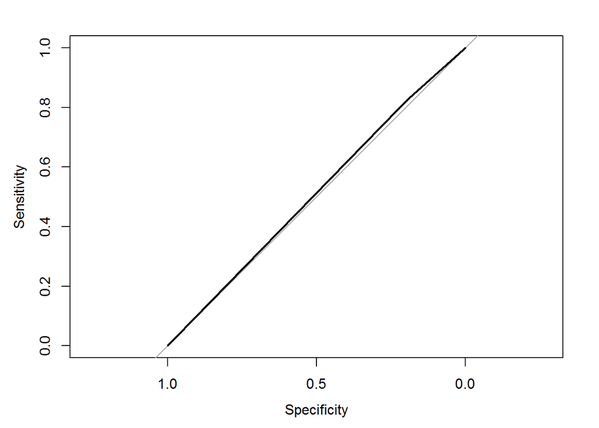

**8. Bagging**  
在此部份中，使用的模形是train函數中method = bagtree 的模型，在此僅先討論沒有mass的情形。 先以80%的training data中的70% training來訓練decision tree模型，並對30%的validation data檢驗結果：

```
## Confusion Matrix and Statistics
##
##           Reference
## Prediction    0    1
##          0 5322  888
##          1  867 9135
##
##                Accuracy : 0.8917
##                  95% CI : (0.8869, 0.8965)
##     No Information Rate : 0.6182
##     P-Value [Acc > NIR] : <2e-16
##
##                   Kappa : 0.7708
##  Mcnemar's Test P-Value : 0.6331
##
##             Sensitivity : 0.8599
##             Specificity : 0.9114
##          Pos Pred Value : 0.8570
##          Neg Pred Value : 0.9133
##              Prevalence : 0.3818
##          Detection Rate : 0.3283
##    Detection Prevalence : 0.3830
##       Balanced Accuracy : 0.8857
##
##        'Positive' Class : 0
##
```

接著針對20%的test data做5次bootstrap cross-testing並計算平均風險，其分類正確率、分類錯誤率、sensitivity與specificity分別如下：

| model | 分類正確率 | 分類錯誤率 | sensitivity | specificity | rmse | AUC |
| --- | --- | --- | --- | --- | --- | --- |
| bagging (bagtree) | 89.27% | 10.73% | 0.8690 | 0.9077 | 0.3274 | 0.8883 |

最後畫出20%的test data的ROC curve：

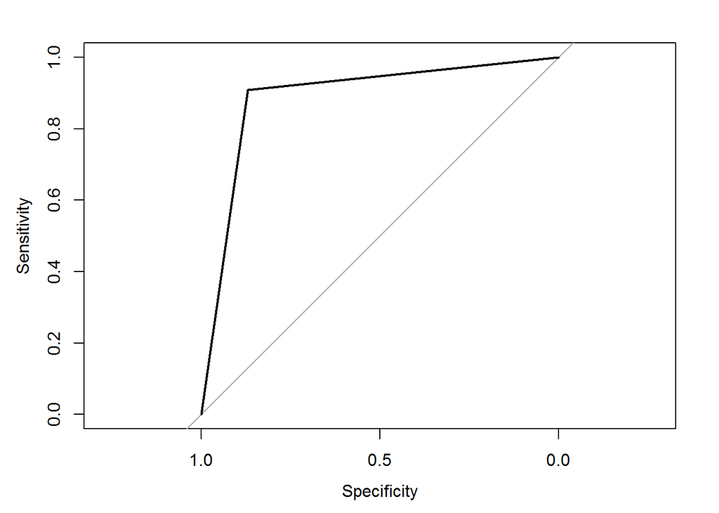

**9. Random Forest**  
礙於時間不足，在此只討論沒有mass的資料集，並先由80%的training data中的70% training的部份子集tune parameter mtry

```
## Random Forest
##
## 3783 samples
##   71 predictor
##    2 classes: '0', '1'
##
## No pre-processing
## Resampling: Cross-Validated (10 fold)
## Summary of sample sizes: 3405, 3405, 3404, 3406, 3404, 3405, ...
## Resampling results across tuning parameters:
##
##   mtry  Accuracy   Kappa
##   2     0.9188465  0.8237081
##   3     0.9381454  0.8665153
##   4     0.9471325  0.8862058
##   5     0.9566451  0.9070105
##
## Accuracy was used to select the optimal model using the largest value.
## The final value used for the model was mtry = 5.
```

由結果可知，mtry在2~5中選擇5應會有較好之結果。 接著以mtry取5的情況，以80%的training data中的70% training來訓練decision tree模型，並對30%的validation data檢驗結果

```
## Confusion Matrix and Statistics
##
##           Reference
## Prediction    0    1
##          0 5323  889
##          1  866 9134
##
##                Accuracy : 0.8917
##                  95% CI : (0.8869, 0.8965)
##     No Information Rate : 0.6182
##     P-Value [Acc > NIR] : <2e-16
##
##                   Kappa : 0.7708
##  Mcnemar's Test P-Value : 0.5995
##
##             Sensitivity : 0.8601
##             Specificity : 0.9113
##          Pos Pred Value : 0.8569
##          Neg Pred Value : 0.9134
##              Prevalence : 0.3818
##          Detection Rate : 0.3283
##    Detection Prevalence : 0.3832
##       Balanced Accuracy : 0.8857
##
##        'Positive' Class : 0
##
```

接著針對20%的test data做5次bootstrap cross-testing並計算平均風險，其分類正確率、分類錯誤率、sensitivity與specificity分別如下：

| model | 分類正確率 | 分類錯誤率 | sensitivity | specificity | rmse | AUC |
| --- | --- | --- | --- | --- | --- | --- |
| Random Forest | 89.68% | 10.32% | 0.8642 | 0.9169 | 0.3211 | 0.8906 |

最後畫出20%的test data的ROC curve：

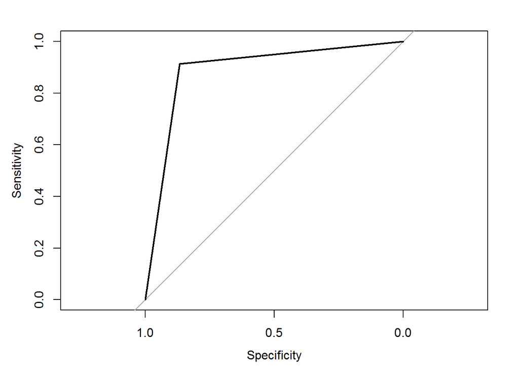

**10. Support Vector Machinesg**  
先由80%的training data中的70% training data 做10-fold CV 訓練SVM模型

```
## Support Vector Machines with Radial Basis Function Kernel
##
## 37832 samples
##    70 predictor
##     2 classes: '0', '1'
##
## No pre-processing
## Resampling: Cross-Validated (10 fold)
## Summary of sample sizes: 34049, 34049, 34048, 34050, 34049, 34049, ...
## Resampling results across tuning parameters:
##
##   C     Accuracy   Kappa
##   0.25  0.8885337  0.7638384
##   0.50  0.8927365  0.7725479
##   1.00  0.8952475  0.7776724
##
## Tuning parameter 'sigma' was held constant at a value of 0.009498523
## Accuracy was used to select the optimal model using the largest value.
## The final values used for the model were sigma = 0.009498523 and C = 1.
```

接著對30%的validation data檢驗結果

```
## Confusion Matrix and Statistics
##
##           Reference
## Prediction    0    1
##          0 5290  813
##          1  899 9210
##
##                Accuracy : 0.8944
##                  95% CI : (0.8896, 0.8991)
##     No Information Rate : 0.6182
##     P-Value [Acc > NIR] : < 2e-16
##
##                   Kappa : 0.7757
##  Mcnemar's Test P-Value : 0.03995
##
##             Sensitivity : 0.8547
##             Specificity : 0.9189
##          Pos Pred Value : 0.8668
##          Neg Pred Value : 0.9111
##              Prevalence : 0.3818
##          Detection Rate : 0.3263
##    Detection Prevalence : 0.3764
##       Balanced Accuracy : 0.8868
##
##        'Positive' Class : 0
##
```

**伍●模型結果比較**

整理各類模型，針對30%的validation data之預測風險如下：

[output not shown]

整理各類模型，針對20%的test data做5次bootstrap cross-testing之平均預測風險如下：

| model | 分類正確率 | 分類錯誤率 | sensitivity | specificity | rmse | AUC |
| --- | --- | --- | --- | --- | --- | --- |
| logistic regression | 86.42% | 13.58% | 0.8269 | 0.9017 | 0.3563 | - |
| logistic regression with one method of variablemodel selections | 87.42% | 12.58% | 0.8970 | 0.8373 | 0.3025 | - |
| logistic rigid regression | 85.92% | 14.08% | 0.8097 | 0.9087 | 0.3595 | - |
| logistic lasso regression | 85.13% | 14.87% | 0.8002 | 0.9024 | 0.369 | - |
| LDA | 87.57% | 12.43% | 0.8205 | 0.9098 | 0.3524 | 0.8652 |
| Decision Tree | 81.76% | 18.24% | 0.6895 | 0.8970 | 0.4269 | 0.7932 |
| kNN (k = 15) | 58.37% | 41.63% | 0.1900 | 0.8262 | 0.6451 | 0.5093 |
| bagging (bagtree) | 89.27% | 10.73% | 0.8690 | 0.9077 | 0.3274 | 0.8883 |
| Random Forest | 89.68% | 10.32% | 0.8642 | 0.9169 | 0.3211 | 0.8906 |
| SVM | 90.14% | 9.86% | 0.8684 | 0.9219 | 0.3138 | 0.8951 |